# Portfolio assignment 13

10 min: Do a bivariate analysis on the penguins dataset for the following combination of columns:

- species VS sex
- island VS sex

For this bivariate analysis, at least perform the following tasks:

- Do you expect their to be a correlation between the two columns?
- Create a contigency table. Do you observe different ratios between categories here?
- Create a bar plot for this contigency table. Do you observe different ratios between categories here?
- Do a chi-squared test. What does the result say? What's the chance of there being a correlation between the two columns?

```python
import pandas as pd
import seaborn as sns
from scipy.stats import chi2_contingency
penguins = sns.load_dataset("penguins")
```

```python
sns.set_theme(style="whitegrid")
```

```python
penguins.head()
```

|  | species | island | bill_length_mm | bill_depth_mm | flipper_length_mm | body_mass_g | sex |
| --- | --- | --- | --- | --- | --- | --- | --- |
| 0 | Adelie | Torgersen | 39.1 | 18.7 | 181.0 | 3750.0 | Male |
| 1 | Adelie | Torgersen | 39.5 | 17.4 | 186.0 | 3800.0 | Female |
| 2 | Adelie | Torgersen | 40.3 | 18.0 | 195.0 | 3250.0 | Female |
| 3 | Adelie | Torgersen | NaN | NaN | NaN | NaN | NaN |
| 4 | Adelie | Torgersen | 36.7 | 19.3 | 193.0 | 3450.0 | Female |

## Species vs Sex

#### Do you expect their to be a correlation between the two columns?

##### Yes.

```python
contingencyTable = penguins.groupby(['species','sex']).size().unstack('species', fill_value=0)
contingencyTable
```

| species sex | Adelie | Chinstrap | Gentoo |
| --- | --- | --- | --- |
| Female | 73 | 34 | 58 |
| Male | 73 | 34 | 61 |

#### Create a contigency table. Do you observe different ratios between categories here?

##### De ratio is op Adelie en Chinstrap 1. Op Gentoo is de ratio net niet 1, dus ja er zijn verschillen in de ratios.

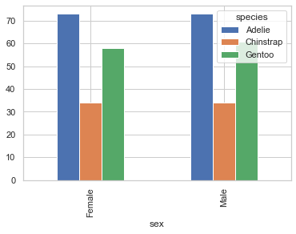

```python
contingencyTable.plot(kind='bar')
```

#### Create a bar plot for this contigency table. Do you observe different ratios between categories here?

##### Klein verschil tussen mannen en vrouwen op Gentoo zoals eerder is aangegeven.

```python
chi2_contingency(contingencyTable)
```

```
(0.04860717014078319,
 0.9759893689765846,
 2,
 array([[72.34234234, 33.69369369, 58.96396396],
        [73.65765766, 34.30630631, 60.03603604]]))
```

## Island vs Sex

#### Do you expect their to be a correlation between the two columns?

##### Yes.

```python
contingencyTable = penguins.groupby(['island','sex']).size().unstack('island', fill_value=0)
contingencyTable
```

| island sex | Biscoe | Dream | Torgersen |
| --- | --- | --- | --- |
| Female | 80 | 61 | 24 |
| Male | 83 | 62 | 23 |

#### Create a contigency table. Do you observe different ratios between categories here?

##### De ratios liggen allemaal dicht bij de 1, echter er zijn wel verschillen in ratios.

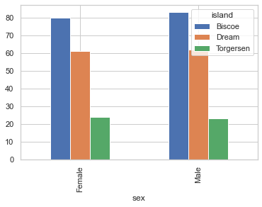

```python
contingencyTable.plot(kind='bar')
```

#### Create a bar plot for this contigency table. Do you observe different ratios between categories here?

##### Klein verschil in ratios zoals eerder is aangegeven.

```python
chi2_contingency(contingencyTable)
```

```
(0.05759904881286206,
 0.971611229281065,
 2,
 array([[80.76576577, 60.94594595, 23.28828829],
        [82.23423423, 62.05405405, 23.71171171]]))
```